# UNICEF HEALTH EXPENSE EFFICIENCY ANALYSIS

### PREPARE DATA

**LOAD DATASET 1: Estimates of Under-five mortality rate by UNICEF region**

*Data is collected from [UNICEF Data Warehouse](https://data.unicef.org/resources/data_explorer/unicef_f/?ag=UNICEF&df=GLOBAL_DATAFLOW&ver=1.0&dq=.CME_MRY0T4..&startPeriod=2009&endPeriod=2019).*

**LOAD DATASET 2: Expense for health per region**

Data is collected from reports:  
[Global annual results report 2019 goal area 1](https://www.unicef.org/media/73351/file/Global-annual-results-report-2019-goal-area-1.pdf), [Global annual results report 2018 goal area 1](https://www.unicef.org/media/54971/file/Global_Annual_Results_Report_2018_Goal_Area_1.pdf), [Annual Results Report 2017 Health](https://www.unicef.org/media/47736/file/Annual_Results_Report_2017_Health.pdf), [Annual Results Report 2016](https://www.unicef.org/media/49126/file/2016arr_health.pdf), [UNICEF Annual Results Report 2015](https://www.unicef.org/media/50046/file/UNICEF_Annual_Report_2015_ENG.pdf), [2014 Annual Results Report health](https://www.unicef.org/media/50731/file/2014_Annual_Results_Report_health.pdf).

**Data Wrangling**

| Region | Year | Under_Five_Mortality_Rate | Health_Expense |
| --- | --- | --- | --- |
| West and Central Africa | 2014 | 108.59 | 445.8 |
| West and Central Africa | 2015 | 105.98 | NA |
| West and Central Africa | 2016 | 103.17 | 494.0 |
| West and Central Africa | 2017 | 100.42 | 437.0 |
| West and Central Africa | 2018 | 97.54 | 370.0 |
| West and Central Africa | 2019 | 94.72 | 346.0 |
| Eastern and Southern Africa | 2014 | 66.80 | 326.1 |
| Eastern and Southern Africa | 2015 | 64.15 | NA |
| Eastern and Southern Africa | 2016 | 61.60 | 378.0 |
| Eastern and Southern Africa | 2017 | 59.40 | 344.0 |

[output cut: 50 more lines]

### MAKE PLOTS

**LEVEL ONE: WORLD ESTIMATES OF UNDER-FIVE MORTALITY RATE VS. UNICEF TOTAL HEALTH EXPENSE IN US MILLIONS PER YEAR**

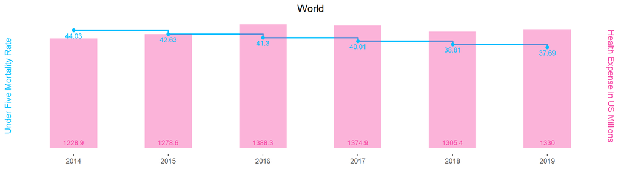

**LEVEL TWO: REGIONAL ESTIMATES OF UNDER-FIVE MORTALITY RATE VS. UNICEF TOTAL HEALTH EXPENSE IN US MILLIONS PER YEAR**

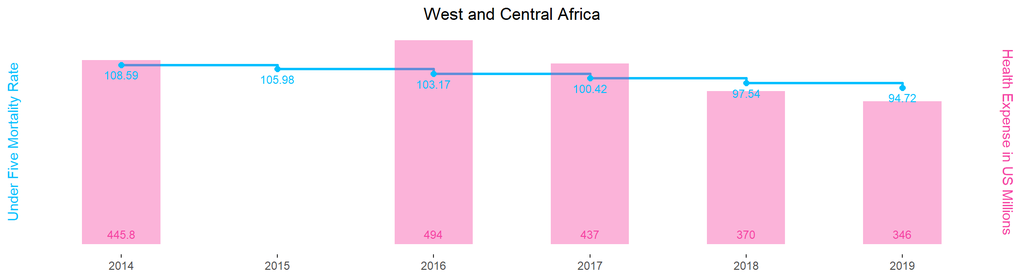

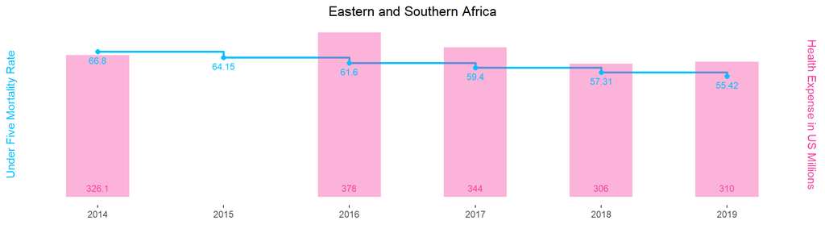

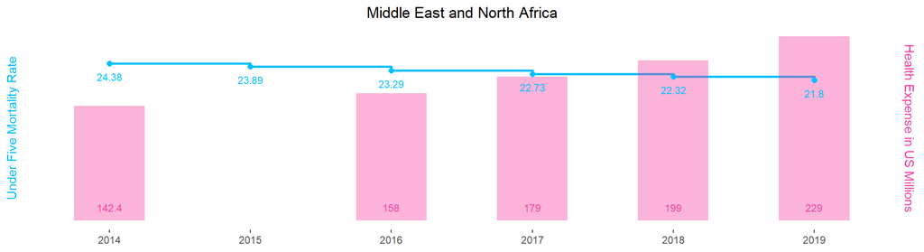

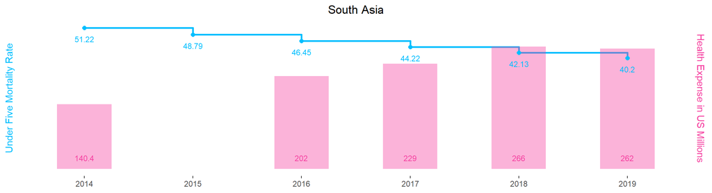

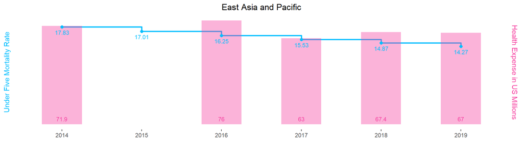

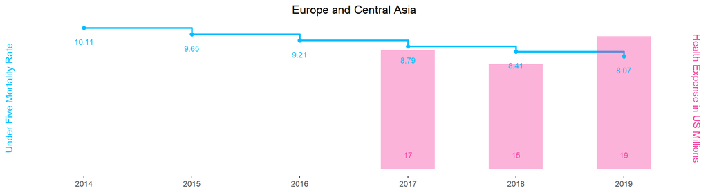

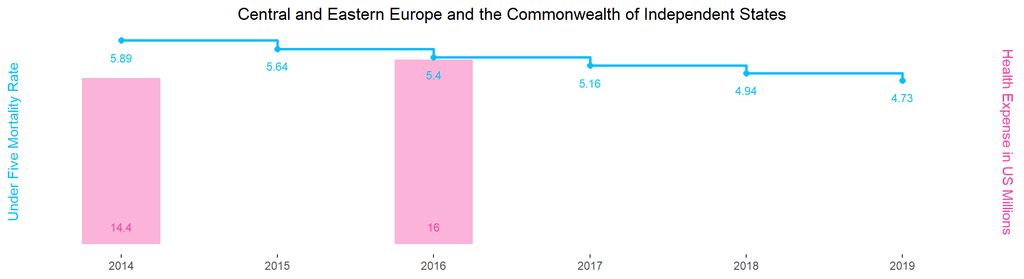

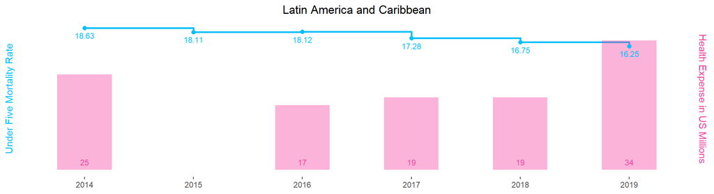

Some interesting trends/movements pop up when looking at plots at the regional level.

For instance, in **Latin America and Caribbean**, health **expense in 2016 dropped** to 17 US millions, and increased 2 US millions in 2017, while Under-five **mortality rate increased** 0.01 in 2016 compared to 2015, and dropped in 2017.

Does the decrease in health expense directly cause the increase of Under-five mortality rate in 2016 in Latin America and Caribbean? If so, by how much? To answer this question, we may need a deeper breakdown of expenses at the **countries level**, and bring in other factors that may cause the increase of mortality rate in that specific year at that specific region. Going forward, we can build **forecasting** model as well to monitor the progress by each country in order to reach the **2030 SDG tagets** together.

*Please note 2015 health expense data is not available at the regional level; all the Under-five mortality rates in the plots are using the median uncertainty bounds.*